# Testes de hipóteses para proporções

ProbEst

fnaufel

(v. 17/09/2021)

# 1 Exemplo: proporção de bebês do sexo masculino

- Um [estudo de 1994 feito em Punjab, na Índia](https://www.bmj.com/content/309/6964/1259.full), relata que $56{,}9\%$ dos $550$ bebês nascidos em um ano em uma maternidade da região eram do sexo masculino.
- Segundo estudos anteriores, $51{,}7\%$ dos bebês nascidos por ano nessa região são meninos.
- Agora que a população tem acesso a exames que determinam o sexo do feto durante a gravidez, existem suspeitas de que fetos do sexo feminino estão sendo abortados pelos pais, por motivos culturais.
- A evidência é suficiente para afirmar que a proporção de bebês meninos na maternidade do estudo é maior do que a proporção da região?

## 1.1 Hipóteses

- Um teste de hipóteses sempre vai ter duas hipóteses.
- A primeira hipótese é a apresentada como “padrão”. Esta é a hipótese que vai ser “desafiada”. O nome técnico para esta hipótese é hipótese de nulidade, ou hipótese nula. A hipótese de nulidade sempre envolve uma igualdade. e costuma ser chamada $H_0$. No exemplo,

  $$H_0 : p = 0{,}517$$

  Ou seja, a proporção de meninos nascidos na maternidade do estudo é de $51{,}7\%$, como no restante da região.
- A segunda hipótese, chamada hipótese alternativa, contradiz de alguma maneira a hipótese de nulidade. No exemplo, vamos trabalhar com

  $$H_A : p > 0{,}517$$

  Ou seja, a verdadeira proporção de meninos nascidos na maternidade do estudo é maior que $51{,}7\%$.

## 1.2 Condições

- O teste de hipóteses também se baseia no TCL.
- Precisamos verificar as condições:
  1. Independência: os sexos dos bebês são independentes entre si? Vamos supor que sim.
  2. Amostra aleatória e representativa: a amostra são os $550$ bebês nascidos na maternidade em questão. Não vamos poder generalizar nossas conclusões para outras maternidades, nem outras regiões. Na verdade, a população consiste em todos os bebês nascidos nessa maternidade, nesse e em outros anos. Vamos supor que os números desse ano são compatíveis com os números de outros anos.
  3. Tamanho da amostra: temos mais do que $30$ elementos, e a amostra é menor do que $10\%$ da população.
  4. Quantidades de sucessos e fracassos potenciais: considerando meninos como sucesso, a hipótese de nulidade diz que deveria haver $550 \times 0{,}517 = 284{,}35$ sucessos e $550 \times 0{,}483 = 265{,}65$ fracassos na amostra, mais do que os $10$ exigidos.

## 1.3 Valores

- Tamanho da amostra: $n = 550$
- Proporção amostral: $\hat p = 0{,}57$
- Hipótese de nulidade: $H_0 : p = 0{,}517$
- Hipótese alternativa: $H_A : p > 0{,}517$
- Nível de confiança: como com os intervalos de confiança, escolhemos $0{,}95$. Mas, em testes de hipóteses, trabalhamos com $1 - 0{,}95 = 0{,}05$ e chamamos este valor de nível de significância, escrito $\alpha = 0{,}05$.

## 1.4 Estratégia

- Sempre começamos supondo que $H_0$ é verdadeira. No exemplo, isto significa supor que $p = 0{,}517$.
- Com isso, construímos a distribuição amostral de $\hat p$, que vai ter como média o valor suposto de $p$.
- Usando esta distribuição amostral, calculamos a probabilidade de obter uma amostra como a que obtivemos (com $\hat p = 0{,}569$) ou mais extrema (com $\hat p > 0{,}569$).
- A probabilidade calculada é chamada de valor $p$.
- Se o valor $p$ for muito baixo, isto indica que, supondo $H_0$, nossa amostra é muito improvável e serve como evidência contra $H_0$. Dizemos, então, que rejeitamos $H_0$.
- Se o valor $p$ for alto, isto indica que, supondo $H_0$, nossa amostra não tem nada de inesperado, e não é evidência contra $H_0$. Não podemos rejeitar $H_0$.
- “Baixo” ou “alto” são definidos em função do nível de significância $\alpha$.

## 1.5 A distribuição amostral de $\hat p$, supondo $H_0$

- Pelo TCL e supondo $H_0$, a distribuição amostral das proporções vai ser normal, com média $\mu = p = 0{,}52$ e erro padrão

  $$\sigma_{\hat p}
  = \sqrt{\frac{p(1-p)}{n}}
  = 0{,}02$$
- Graficamente:

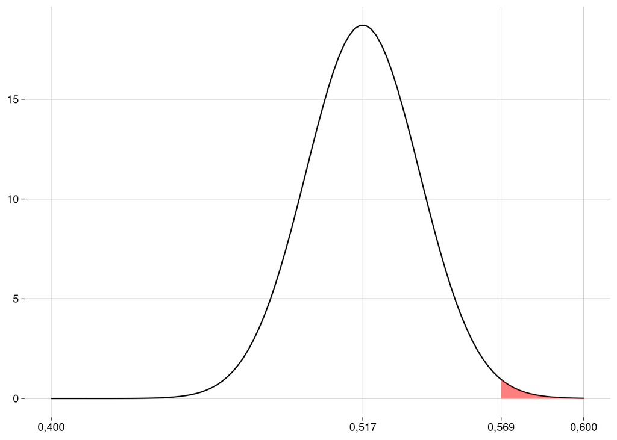

## 1.6 O valor $p$ e a conclusão

- O valor $p$ vai ser a probabilidade que corresponde à área em vermelho, que pode ser calculada em R:

  ```r
  n <- 550
  p_chapeu <- 0.569
  p0 <- 0.517
  ep <- sqrt(p0 * (1 - p0) / n)
  valor_p <- pnorm(p_chapeu, mean = p0, sd = ep, lower.tail = FALSE)
  valor_p
  ```

  ```
  ## [1] 0,007334952
  ```

- Este valor é muito menor do que $\alpha = 0{,}05$. Logo, nossa amostra é evidência para rejeitar a hipótese de nulidade neste nível de significância. Concluímos que essa maternidade tem uma proporção de nascimentos de meninos maior do que $0{,}52$, com $\alpha = 0{,}05$.
- Outros níveis de significância usados na prática são $\alpha = 0{,}1$ (menos exigente) e $\alpha = 0{,}01$ (mais exigente). Em algumas áreas, como na Física, são usados níveis de significância mais exigentes ainda, como $\alpha = 0{,}0000003$ no [experimento que confirmou a existência do bóson de Higgs](https://medium.com/@chris.m.pease/the-higgs-boson-and-5-sigma-eec238b43f93).

## 1.7 Em R

```r
prop.test(
  x = p_chapeu * n,          # número de sucessos
  n = n,                     # tamanho da amostra
  p = p0,                    # valor de p na hipótese de nulidade
  alternative = 'greater',   # hipótese alternativa é p > p0
  conf.level = .95,          # 1 - α (o default já é .95)
  correct = FALSE            # sem correção de continuidade
)
```

```
##
##  1-sample proportions test without continuity correction
##
## data:  p_chapeu * n out of n, null probability p0
## X-squared = 5,9557, df = 1, p-value = 0,007335
## alternative hypothesis: true p is greater than 0,517
## 95 percent confidence interval:
##  0,5340128 1,0000000
## sample estimates:
##     p
## 0,569
```

# 2 Exemplo: percepção extra-sensorial

- Um suposto vidente alega que consegue detectar os naipes de cartas colocadas viradas para baixo, diante dele, em uma mesa.
- Em um experimento, um pesquisador apresenta ao suposto vidente $50$ cartas, escolhidas ao acaso dentre as cartas de $10$ baralhos, e o suposto vidente acerta o naipe de $10$ delas.
- O pesquisador diz ao suposto vidente que ele teve *menos* acertos do que se ele tivesse adivinhado ao acaso: $50 \times 1/4 = 12{,}50$.
- O suposto vidente diz que isso também é evidência dos seus poderes: os erros foram causados por “interferência”, pois o suposto vidente estava captando informações sobre o naipe da carta, mas não conseguiu interpretá-las corretamente.

## 2.1 Hipóteses

- A hipótese de nulidade diz que o suposto vidente não tem poderes; a verdadeira proporção de acertos sempre vai ser, a princípio, $1/4$ da quantidade de cartas:

  $$p = 0{,}25$$
- A hipótese alternativa reflete os argumentos do suposto vidente de que uma proporção significativamente maior ou significativamente menor do que $25\%$ indica a existência de poderes extra-sensoriais:

  $$p \neq 0{,}25$$
- A hipótese alternativa, agora, vai gerar um teste bilateral.

## 2.2 Condições

1. Independência: Vamos supor que acertar o naipe de uma carta independe de acertar o naipe de outra carta. Por exemplo, podemos supor que a dificuldade de acertar o naipe de uma carta é sempre a mesma, independente da carta, da ordem em que elas aparecem etc. O fato de que as $50$ cartas foram escolhidas dentre $10$ baralhos ($520$ cartas, no total) nos permite considerar que os naipes das cartas escolhidas são independentes. Além disso, se não quisermos que o suposto vidente “conte” os naipes das cartas durante o experimento, podemos decidir só revelar os naipes das $50$ cartas *depois* que o suposto vidente tiver registrado seus palpites.
2. Amostra aleatória e representativa: A população é o conjunto de todas as cartas que poderiam ser escolhidas para o suposto vidente poder exercer seus poderes. As $50$ cartas, escolhidas ao acaso, representam de forma adequada esta população.
3. Tamanho da amostra: temos mais do que $30$ elementos, e a amostra é menor do que $10\%$ da população (que é infinita).
4. Quantidades de sucessos e fracassos potenciais: a hipótese de nulidade diz que deveria haver $50 \times 1/4 = 12{,}50$ sucessos e $50 \times 3/4 = 37{,}50$ fracassos na amostra, mais do que os $10$ exigidos.

## 2.3 Valores

- Tamanho da amostra: $n = 50$
- Proporção amostral: $\hat p = 0{,}20$
- Hipótese de nulidade: $H_0 : p = 0{,}25$
- Hipótese alternativa: $H_A : p \neq 0{,}25$
- Nível de significância: $\alpha = 0{,}05$

## 2.4 Estratégia

- Começamos supondo que $H_0$ é verdadeira: $p = 0{,}25$.
- Com isso, construímos a distribuição amostral de $\hat p$, que vai ter como média o valor suposto de $p$.
- Usando esta distribuição amostral, calculamos a probabilidade de obter uma amostra como a que obtivemos ou mais extrema (mais distante de $0{,}25$).

## 2.5 A distribuição amostral de $\hat p$, supondo $H_0$

- Pelo TCL e supondo $H_0$, a distribuição amostral das proporções vai ser normal, com média $\mu = p = 0{,}25$ e erro padrão

  $$\sigma_{\hat p}
  = \sqrt{\frac{p(1-p)}{n}}
  = 0{,}06$$
- Graficamente:

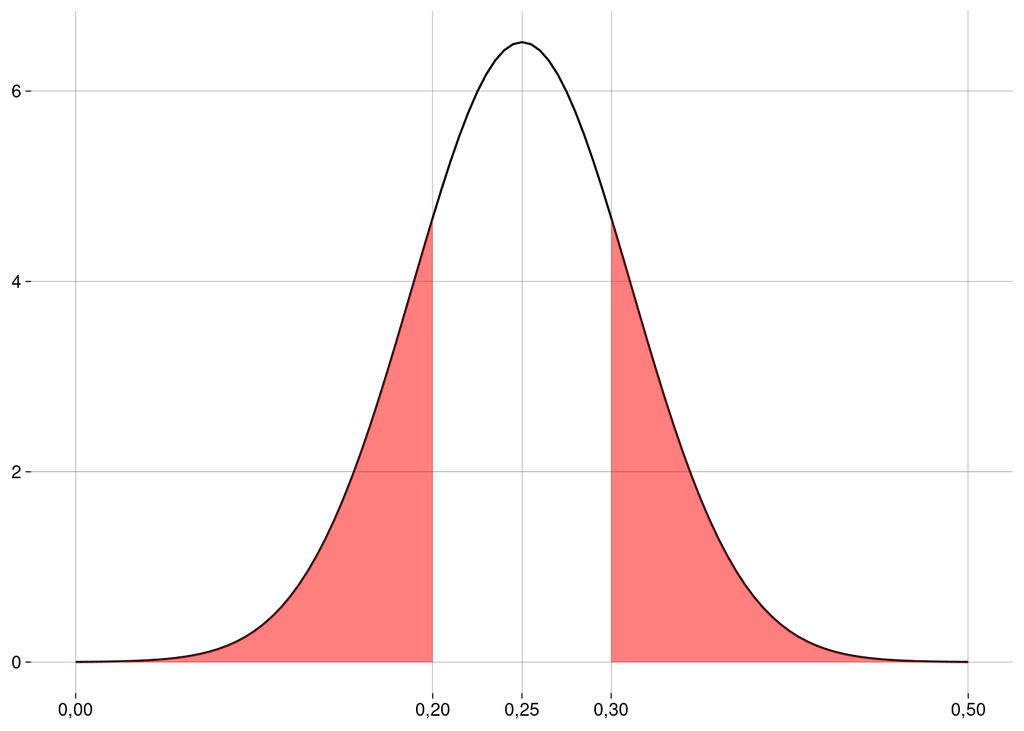

## 2.6 O valor $p$ e a conclusão

- O valor $p$ vai ser a probabilidade que corresponde à área em vermelho, que pode ser calculada em R:

  ```r
  sucessos <- 10
  n <- 50
  p0 <- 1/4
  p_chapeu <- sucessos / n
  ep <- sqrt(p0 * (1 - p0) / n)
  p_cauda_direita <- p0 + (p0 - p_chapeu)
  valor_p <-
    pnorm(p_chapeu, mean = p0, sd = ep) +
    pnorm(p_cauda_direita, mean = p0, sd = ep, lower.tail = FALSE)
  valor_p
  ```

  ```
  ## [1] 0,4142162
  ```

- Este valor é maior do que $\alpha = 0{,}05$. Logo, nossa amostra não é evidência para rejeitar a hipótese de nulidade neste nível de significância.

## 2.7 Em R

```r
prop.test(
  x = sucessos,              # número de sucessos
  n = n,                     # tamanho da amostra
  p = p0,                    # valor de p na hipótese de nulidade
  alternative = 'two.sided', # hipótese alternativa é p != p0
  conf.level = .95,          # 1 - α (o default já é .95)
  correct = FALSE            # sem correção de continuidade
)
```

```
##
##  1-sample proportions test without continuity correction
##
## data:  sucessos out of n, null probability p0
## X-squared = 0,66667, df = 1, p-value = 0,4142
## alternative hypothesis: true p is not equal to 0,25
## 95 percent confidence interval:
##  0,1124375 0,3303711
## sample estimates:
##   p
## 0,2
```

# 3 Erros, poder e tamanho do efeito

## 3.1 Rejeitar $\times$ não rejeitar

- Em um teste de hipóteses, nada é provado.
- Se o valor $p$ for menor do que $\alpha$, você deve concluir que existem evidências para rejeitar a hipótese de nulidade.
- Se o valor $p$ for maior do que $\alpha$, você deve concluir que não existem evidências para rejeitar a hipótese de nulidade.
- Seja como for, você deve incluir na sua conclusão
  - As hipóteses.
  - O valor da estatística envolvida no teste (aqui, a proporção amostral).
  - O tamanho da amostra.
  - O valor de $\alpha$.
  - O valor $p$.
  - A informação de se o teste é unilateral ou bilateral.
- Como nada é provado, existe a possibilidade de acontecer um erro:
  - Você pode rejeitar $H_0$ quando ela é verdadeira, ou
  - Você pode não rejeitar $H_0$ quando ela é falsa.

## 3.2 Erro tipo 1: rejeitar quando não devíamos

- Falso positivo.
- Diagnosticar como doente um paciente saudável.
- Condenar um réu inocente.
- Um erro tipo $1$ só acontece quando a hipótese de nulidade é verdadeira.
- A probabilidade de um erro tipo $1$ acontecer é a probabilidade de a nossa amostra ser uma amostra “ruim”.
- Mas a probabilidade de a amostra ser ruim é exatamente $\alpha$.
- Então, a probabilidade de um erro tipo $1$ é sempre igual a $\alpha$.

## 3.5 O tamanho do efeito

- Diferença entre o valor do parâmetro em $H_0$ e o valor verdadeiro do parâmetro.
- Efeitos maiores são mais fáceis de detectar.
- Efeitos menores são mais difíceis de detectar.
- O poder de um teste também depende do tamanho do efeito.

## 3.6 Explorando tudo interativamente

- https://rpsychologist.com/d3/nhst/

# 4 Exercícios

## 4.1 Usando `binom.test`

- No exemplo dos bebês, calcule a *quantidade* de nascimentos de meninos na amostra. O que há de estranho?
- A função `binom.test`, de R base, também faz teste de hipótese para a proporção (embora usando um algoritmo diferente do nosso). Rode o seguinte código:

  ```r
  binom.test(
    x = p_chapeu * n,          # número de sucessos
    n = n,                     # tamanho da amostra
    p = p0,                    # valor de p na hipótese de nulidade
    alternative = 'greater',   # hipótese alternativa é p > p0
    conf.level = .95           # 1 - α
  )
  ```

  O que dá errado? Por quê? Como consertar?

## 4.2 Outro suposto vidente

- O experimento do exemplo é repetido com outra pessoa, que acerta o naipe de $17$ das $50$ cartas. Refaça o teste de hipóteses com este novo valor, de duas maneiras:
  1. Com um teste bilateral: $H_A : p \neq 0{,}25$.
  2. Com um teste unilateral: $H_A : p > 0{,}25$.
- Quais as suas conclusões?